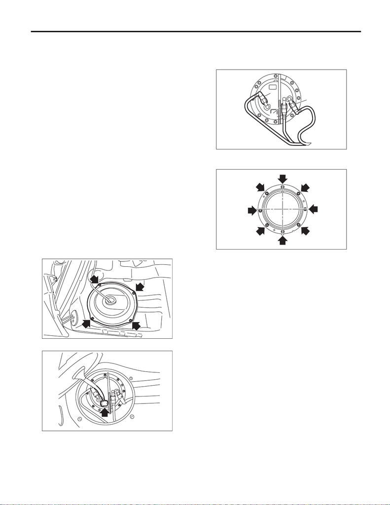

FU(STI)-82

Fuel Pump

FUEL INJECTION (FUEL SYSTEMS)

29.Fuel Pump

A: REMOVAL

WARNING:

Place “NO OPEN FLAMES” signs near the

working area.

CAUTION:

• Be careful not to spill fuel.

• Catch the fuel from the tubes using a contain-

er or cloth.

• If the fuel gauge indicates that two thirds or

more of the fuel is remaining, be sure to drain

fuel before starting work to avoid the fuel to

spill.

NOTE:

Fuel pump assembly consists of fuel pump, fuel fil-

ter and fuel level sensor.

1) Release the fuel pressure. <Ref. to FU(STI)-64,

RELEASING OF FUEL PRESSURE, PROCE-

DURE, Fuel.>

2) Drain fuel. <Ref. to FU(STI)-64, DRAINING

FUEL (WITH SUBARU SELECT MONITOR),

PROCEDURE, Fuel.>

3) Disconnect the ground cable from battery.

4) Remove the rear seat cushion. <Ref. to SE-29,

REMOVAL, Rear Seat.>

5) Remove the service hole cover.

6) Disconnect the connector from fuel pump.

7) Disconnect the quick connectors of fuel delivery

tube (A), fuel return tube (B), and jet pump tube (C).

<Ref. to FU(STI)-94, REMOVAL, Fuel Delivery,

Return and Evaporation Lines.>

8) Remove the nuts which hold the fuel pump up-

per plate to the fuel tank.

9) Remove the fuel pump assembly from the fuel

tank.

FU-08350

FU-08311

FU-08310

(A)

(B)

(C)

FU-04534

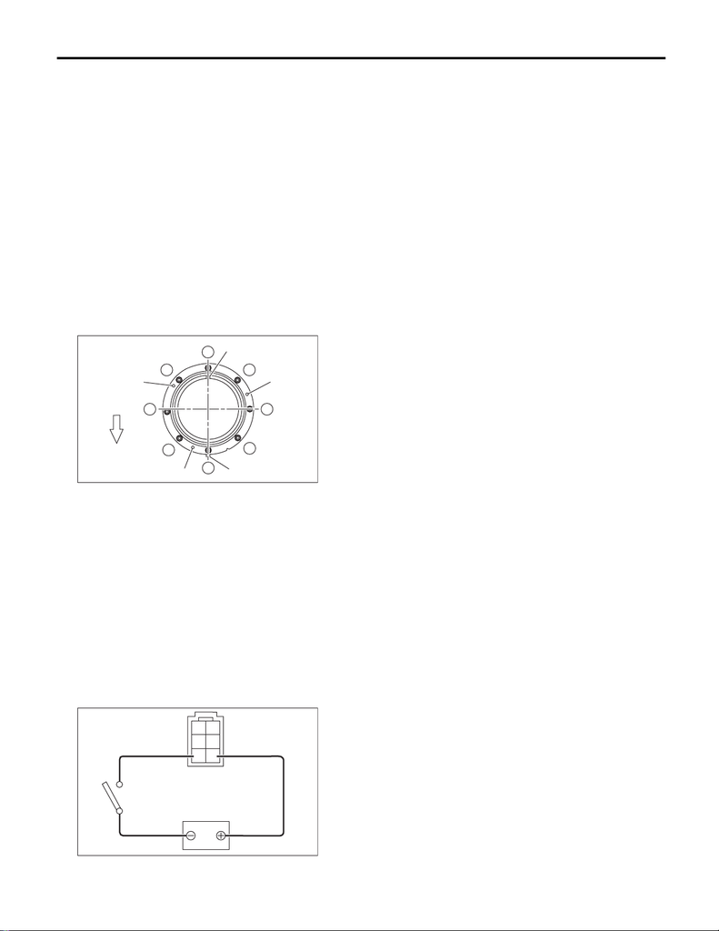

FU(STI)-83

Fuel Pump

FUEL INJECTION (FUEL SYSTEMS)

B: INSTALLATION

Install in the reverse order of removal while being

careful of the following.

• Make sure the sealing portion is free from fuel or

foreign matter before installation.

• Align protrusion (A) of the gasket to the position

shown in the figure.

• Insert the protrusion (B) of gasket to the fuel

pump upper plate. (3 places)

• Align the protrusion (C) of fuel pump assembly

with the cutout on the fuel pump upper plate.

• Tighten the nuts to the specified torque in the or-

der as shown in the figure.

NOTE:

Use a new gasket.

Tightening torque:

4.4 N·m (0.4 kgf-m, 3.2 ft-lb)

C: INSPECTION

1) Check that the fuel pump has no deformation,

cracks or other damages.

2) Connect the battery positive terminal to terminal

No. 5 and the battery ground terminal to terminal

No. 6, and inspect the fuel pump operation.

WARNING:

• Wipe off fuel completely.

• Keep the battery as far apart from fuel pump

as possible.

• Do not run the fuel pump for a long time un-

der non-load condition.

(a) Front side of vehicle

FU-04532

1

2

3

4

5

6

7

8

(C)

(B)

(B)

(B)

(A)

(a)

FU-04110